# Documento2do Corte

Raul Pinilla

2023-10-08

## Summary of the dataset necessary to understand the exercise

#### People with diabetes

no diabetes=0; prediabetes=1; diabetes= 2

#### People with high Blood Pressure (BP)

No high BP= 0; High BP = 1

#### People with high cholesterol

No high cholesterol= 0; high cholesterol = 1

#### Cholesterol control in the last 5 years (CholCheck)

No CholCheck= 0; Yes cholesterol control in 5 years = 1

#### BMI: body mass index

#### Smoker: Have you smoked at least 100 cigarettes in your entire life? [Note: 5 packs = 100 cigarettes]

No= 0; Yes= 1

#### Stroke: (Were you ever told) that you had a stroke.

No= 0; Yes= 1

#### HeartDiseaseorAttack: Coronary heart disease (CHD) or myocardial infarction (MI)

No=0; Yes= 1

#### PhysActivity: physical activity in the last 30 days - not including work

No=0; Yes= 1

#### Fruits: Consume fruit 1 or more times a day

No=0; Yes= 1

#### Vegetables: Eat Vegetables 1 or more times a day

No=0; Yes= 1

#### HvyAlcoholConsump: (adult men >=14 drinks per week and adult women >=7 drinks per week)

No=0; Yes= 1

#### AnyHealthcare: Have any type of health care coverage, including health insurance, prepaid plans such as HMOs,etc.

No=0; Yes= 1

#### NoDocbcCost: Was there a time in the last 12 months when you needed to see a doctor but couldn’t because cost?

No=0; Yes= 1

#### GenHlth: Would you say that in general your health is: scale 1-5

1 = excellent; 2 = very good; 3 = good; 4 = fair; 5 =poor

#### MentHlth: days of poor mental health scale 1-30 days

#### PhysHlth: days of illness or physical injury in the last 30 days scale 1-30

#### DiffWalk: Do you have serious difficulties walking or climbing stairs?

No=0; Yes= 1

#### Sex:

Female=0; Male=1

#### Age: 13-level age category (_AGEG5YR see codebook)

18-24=1; 60-64=9; 80 or more=13

#### Education: Educational level (EDUCA see code book)

Scale 1-6 1 = Never attended school or only kindergarten 2 = elementary etc.

#### Income: Income scale (INCOME2 see codebook)

Less than $10,000= scale 1-8 1; Less than $35,000= 5; $75,000 or more= 8

#### Summary of the variables in the dataset

0 = no diabetes 1 = prediabetes 2 = diabetes

## Data exploration and data wrangling

Where:

“data” loads specified data sets or lists available data sets.

“read.delim” = Reads a file in table format and creates a data frame from it, with cases corresponding to lines and variables to fields in the file.

I used “clipboard” to paste the data from diabetes_012_health_indicators_BRFSS2015.csv since I had it in an excel file and I clicked run on the code to save it.

“Data” We use it to review the data in general, where it tells us that we have 22 variables and 253680 observations.

## Variables present in the database

“Str” is used to view each of the variables contained in the database.

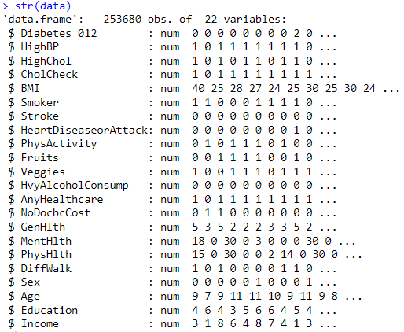

Variables

## First Observations

With the “head” function it shows me the first observations of the ENTIRE database.

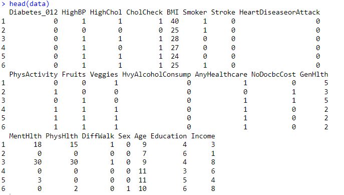

Variables

## Ultimas Observaciones

With the “tail” function it shows me the latest observations of the ENTIRE database.

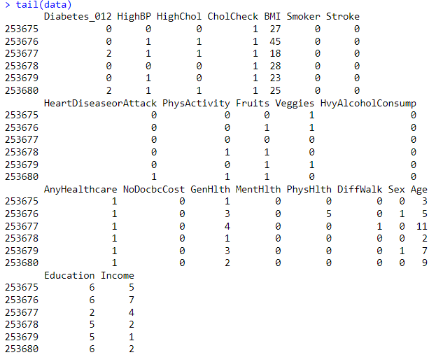

Variables

## General Summary

With the “summary” function it shows me a summary of the ENTIRE database, discriminating for each variable, the mean, median, minimum, maximum and others.

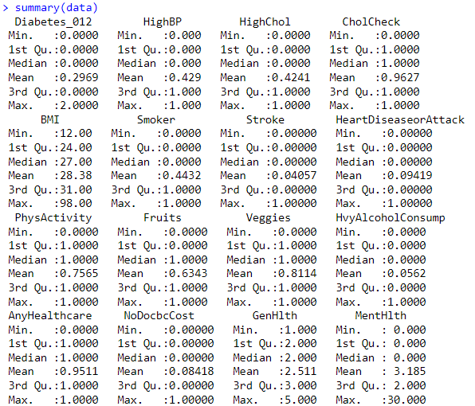

##### To see the summary of each variable you must use the “attach” function

Now it is possible to request the summary or the mean, or median among others for each variable

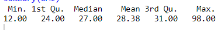

[figure not shown]

Variables

## Database Sampling

I will start using the following function, which allows me to choose a specific sample. If I don’t have it, every time I compile the code it will show me a different sample.

#### We will call a new variable for the random sample and select the number of observations to show, I chose 500

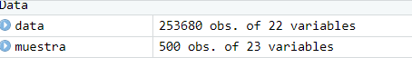

[figure not shown]

#### I will show a sample bar graph

[figure not shown]

Variables

#### You can also show a pie chart but it is more useful in categorical variables, in this case select only 50 observations so that it looks better

[figure not shown]

Variables

## Graph correlation, the closest to diabetes is the body mass index “BMI”

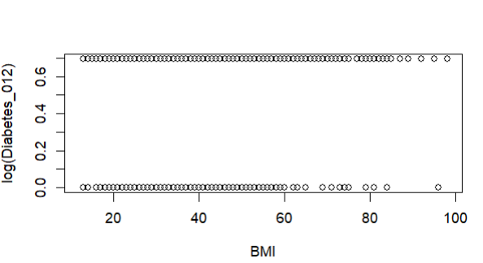

Variables

### To check how many people have diabetes, prediabetes or do not have in numerical values

Variables

#### We call a new variable new to change the variable from numeric to categorical. The function “as.factor” is used to encode a vector as a factor (the terms “category” and “enumerated type” are also used for factors).

#### Taking into account what was provided by the teacher, it is taken into account that patients without diabetes are represented as 0, prediabetes 1 and diabetes 2

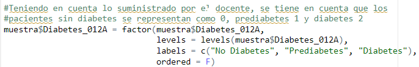

Variables

### With the levels function, it links 0, 1 and 2 of the variable Diabetes_012 and then with labels I place the names that I will change, in this case, no diabetes, prediabetes and diabetes.

#Create a table that shows me how many patients have diabetes, how many do not, and how many have prediabetes.

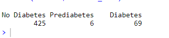

Variables